## MA2102

# Probability and Statistics

#### Lecture-22

## Multinomial Distribution:

One of the most important multivariate distribution is the Multinomial distribution, which arises when a sequence of $n$ independent and identical experiments performed which results in any one of $k$($\ge2$) possible outcomes

Let us denote the $k$ possible outcomes of the experiment as $r_1,r_2,...r_k$, and $p_i$ is probability of obtaining outcome $r_i$ when experiment is performed for $i=1,2,...,k$, so $\sum_{i=1}^kp_i=1$

Here we are performing sequence of $n$ independent and identical experiments of above kind.

$\Omega=\{\omega:\omega=x_1x_2...x_n, x_i\in \{r_1,r_2,...,r_k\} \text{ for } i=1,2,...n\}$

For $n_i\ge 0$ & $\sum_{i=1}^{k}n_i=n$

define $E_{n_1n_2...n_k}=\{\omega \in \Omega:\text{ number of $r_i$'s in $\omega$ = $n_i$ for i=1,2,...k}\}$

$|E_{n_1n_2...n_k}|=\frac{n!}{n_1!n_2!...n_k!}$

for $\omega \in E_{n_1n_2...n_k}$, $P(\{\omega\})=p_1^{n_1}p_2^{n_2}...p_k^{n_k}$ ($\because$ Independence)

Let $X_i=$ number of $r_i$'s in $n$ trials for $i=1,2,...k$

$JPMF$ of $\underline{X}=(X_1,X_2,...,X_k)$

$S_\underline{X}=\{(n_1,n_2,...,n_k):n_1\ge 0,n_2\ge 0,...,n_k\ge 0, \sum_{i=1}^kn_i=n \}$

$p_{\underline{X}}(n_1,n_2,...,n_k)=P(X_1=n_1,X_2=n_2,...,X_k=n_k)=P(E_{n_1n_2...n_k})=\underset{\omega\in E_{n_1n_2...n_k}}{\sum}P(\{\omega\})$

$=\underset{\omega\in E_{n_1n_2...n_k}}{\sum}p_1^{n_1}p_2^{n_2}...p_k^{n_k}=\left(\underset{\omega\in E_{n_1n_2...n_k}}{\sum}1\right)p_1^{n_1}p_2^{n_2}...p_k^{n_k}$

$=|E_{n_1n_2...n_k}|p_1^{n_1}p_2^{n_2}...p_k^{n_k}=\frac{n!}{n_1!n_2!...n_k!}p_1^{n_1}p_2^{n_2}...p_k^{n_k}$

$\therefore$ $p_{\underline{X}}(n_1,n_2,...,n_k)=\binom{n}{n_1,n_2,\dots,n_k}p_1^{n_1}p_2^{n_2}...p_k^{n_k}$

Where (Multinomial Coefficient) $\binom{n}{n_1,n_2,\dots,n_k}:=\frac{n!}{n_1!n_2!...n_k!}$

### Validity of $JPMF$ of $\underline{X}$ :

1. $p_{\underline{X}}(n_1,n_2,...,n_k)\ge 0$
1. $\sum_{(n_1,n_2,...,n_k)\in S_{\underline{X}}}\binom{n}{n_1,n_2,\dots,n_k}p_1^{n_1}p_2^{n_2}...p_k^{n_k}=\left(p_{1}+p_{2}+...+p_{k}\right)^n=(1)^n=1$ ($\because$ $p_{1}+p_{2}+...+p_{k}=1$ and Multinomial theorem)

**Notation:** $\underline{X}=(X1,X_2,...,X_k)\sim Multi(n,(p_1,p_2,\dots,p_k))$

**Note:** Binomial distribution with parameter $n,p$ is equivalent to Multinomial distribution with parameter $n$,(p,1-p) (i.e $Bin(n,p)\equiv Multi(n,(p_1,p_2))$) where $p_1=p, p_2=1-p$

**Example:** Let us say we have a die whose probabilities of landing on outcomes 1,2,3,4,5,6 respectively are $\frac{1}{5},\frac{3}{10},\frac{1}{5},\frac{1}{10},\frac{1}{20},\frac{3}{20}$. And if we roll die 9 times, then find the probability that 1 appear three times, 2 and 3 appear twice each, 4 and 5 once each and 6 not at all.

*solution:*Let $X_i=$ number of $i$'s in 9 trials for $i=1,2,3,...,6$

then $(X_1,X_2,...,X_6)\sim Multi\left(9,(\frac{1}{5},\frac{3}{10},\frac{1}{5},\frac{1}{10},\frac{1}{20},\frac{3}{20})\right)$

Here we are interested in $P(X_1=3,X_2=2,X_3=2,X_4=1,X_5=1,X_6=0)=?$

$P(X_1=3,X_2=2,X_3=2,X_4=1,X_5=1,X_6=0)=\frac{9!}{3!2!2!1!1!0!}\left(\frac{1}{5}\right)^3\left(\frac{3}{10}\right)^2\left(\frac{1}{5}\right)^2\left(\frac{1}{10}\right)^1\left(\frac{1}{20}\right)^1\left(\frac{3}{20}\right)^0=0.00217728$

### Distribution of sum of two independent random variables:

Suppose $X,Y$ are independent continuous random variable having $PDF$'s $f_X(x)$, $f_Y(y)$ respectively, then $CDF$ of $X+Y$,

$F_{X+Y}(t)=P(X+Y\le t)$

$=\underset{x+y\le t}{\int\int}f_{X,Y}(x,y)dxdy$

$={\int_{-\infty}^{\infty}\int_{-\infty}^{t-y}}f_X(x)f_Y(y)dxdy$ ($\because X,Y$ are independent, we have $f_{X,Y}(x,y)=f_X(x)f_Y(y)$)

$=\int_{-\infty}^{\infty}\left[\int_{-\infty}^{t-y}f_X(x)dx\right]f_Y(y)dy$

$\therefore$ $F_{X+Y}(t)=\int_{-\infty}^{\infty}F_{X}(t-y)f_Y(y)dy$

$f_{X+Y}(t)=\frac{d}{dt}F_{X+Y}(t)=\frac{d}{dt}\left[\int_{-\infty}^{\infty}F_X(t-y)f_Y(y)dy\right]$

$f_{X+Y}(t)=\int_{-\infty}^{\infty}\frac{d}{dt}F_X(t-y)f_Y(y)dy$ ($\because~$ Leibniz integral rule)

$\fbox{$\therefore$ $f*{X+Y}(t)=\int*{-\infty}^{\infty}f_X(t-y)f_Y(y)dy$}$

Here $f_{X+Y}$ is called *convolution* of $f_X$, $f_Y$

**Example:** $X,Y$ are independent, $X\sim U[0,1]$, and $Y\sim U[0,1]$, then calculate the $PDF$ of $X+Y$

*solution:* The $PDF$ of $X+Y$, $f_{X+Y}(t)=\int_{-\infty}^{\infty}f_X(t-y)f_Y(y)dy$

$f_{X+Y}(t)=\int_{0}^{1}f_X(t-y)dy$ ($\because$ $f_Y(y)=\left\{\begin{matrix} 1&0<y<1 \\ 0& \text{otherwise} \end{matrix}\right.$)

$S_X=[0,1]$, $S_Y=[0,1]$, then $S_{X+Y}=[0,2]$

$f_X(t-y)=1\iff$ $0<t-y<1\iff -1<y-t<0\iff t-1<y<t$ $\left(\because f_X(x)=\left\{\begin{matrix} 1&0<x<1 \\ 0& \text{otherwise} \end{matrix}\right.~~~~~\right)$

for $0\le t\le 1$, $f_{X+Y}(t)=\int_0^tdy=t$ ---t-1-----0-----t---------1

for $1<t\le 2$, $f_{X+Y}(t)=\int_{t-1}^1dy=2-t$ ---0-----t-1---1-----t---2

$\therefore$ $f_{X+Y}(t)=\left\{\begin{matrix} t& 0\le t \le 1\\ 2-t& 1<t\le2 \\ 0 & \text{otherwise} \end{matrix}\right.$  
Because of the shape of it's $PDF$, $X+Y$ is said to have **Triangular distribution**

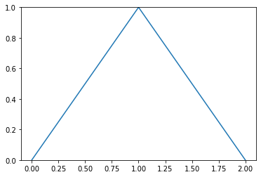

```python
import matplotlib.pyplot as plt
plt.plot([0,1,2],[0,1,0])
plt.ylim(0,1)
plt.show()
```

Suppose $X,Y$ are independent discrete random variables with $PMF$'s $p_X$,$p_Y$ respectively, then $PMF$ of $X+Y$

$p_{X+Y}(t)=P(X+Y=t)=P(\underset{x\in S_X}{\bigcup}(X=x,Y=t-x))$

$=\underset{x\in S_X}{\sum}P(X=x,Y=t-x)$

$=\underset{x\in S_X}{\sum}P(X=x)P(Y=t-x)$ ($\because~X,Y$ are independent)

$p_{X+Y}(t)=\underset{x\in S_X}{\sum}p_X(x)p_Y(t-x)$

$\therefore$ Here $p_{X+Y}$ is called convolution of $p_X,p_Y$

**Example:** Let $X,Y$ are independent and $X\sim Bin(m,p)$, $Y\sim Bin(n,p)$ , then $S_X=\{0,1,2,...,m\}$, $S_Y=\{0,1,2,...,n\}$

$S_{X+Y}=\{0,1,2,...,m+n\}$

$p_X(x)=\binom{m}{x}p^x(1-p)^{m-x}$, $x\in S_X$, $p_Y(y)=\binom{n}{y}p^y(1-p)^{n-y}$,$y\in S_Y$

$PMF$ of $X+Y$, $p_{X+Y}(t)=\sum_{x=0}^{n}p_X(x)p_Y(t-x)$ ($\because$ Convolution formula)

$=\sum_{x=0}^{n}\left[\binom{m}{x}p^x(1-p)^{m-x}\right]\left[\binom{n}{t-x}p^{t-x}(1-p)^{n-(t-x)}\right]$ ($\because$ Convolution formula)

$=\left[\sum_{x=0}^{n}\binom{m}{x}\binom{n}{t-x}\right]p^{t}(1-p)^{m+n-t}$

$=\binom{m+n}{t}p^{t}(1-p)^{m+n-t}$ ($\because$ Vandermonde's Identity)

$\therefore$ $X+Y\sim Bin(m+n,p)$

## Transformations in $\mathbb{R}^k$

**Theorem:** Let $\underline{X}\equiv(X_1,X_2,...,X_k)$ be k-dimensional random vector of continuous type with $JPDF$ $f_{\underline{X}}(x_1,x_2,...,x_k)$, with support $S_{\underline{X}}$

$Y_i=g_i(X_1,X_2,...,X_k)$ for $i=1,2,...,k$, which maps $S_{\underline{X}}$ to $S_{\underline{Y}}$and functions $g_i$'s have continuous partial derivatives,

and we suppose that equations $y_i=g_i(x_1,x_2,...,x_k)$ for i=1,2,...,k have a unique solutions, say $x_i=h_i(y_1,y_2,...,y_k)$ for i=1,2,...,k

and Jacobian $\frac{\partial(x_1,x_2,...,x_k)}{\partial(y_1,y_2,...,y_k)}=det\left[\frac{\partial x_i}{\partial y_j}\right]_{k\times k}\ne 0$

Under these assumptions, the $JPDF$ of $\underline{Y}\equiv(Y_1,Y_2,...,Y_k)$ is given by

$f_{\underline{Y}}(y_1,y_2,...,y_k)=f_{\underline{X}}(h_1(y_1,y_2,...,y_k),h_2(y_1,y_2,...,y_k),...,h_k(y_1,y_2,...,y_k))\begin{vmatrix}\frac{\partial(x_1,x_2,...,x_k)}{\partial(y_1,y_2,...,y_k)}\end{vmatrix}$, $(y_1,y_2,...,y_k)\in S_{\underline{Y}}$

**Example:** Let $(X,Y)$ be bivariate random variable with $JPDF$ $f_{X,Y}(x,y)$,$U=X+Y$, $V=X-Y$

Let $u=x+y$, $v=x-y\implies$ $x=\frac{u+v}{2}$, $y=\frac{u-v}{2}$

$\frac{\partial(x,y)}{\partial(u,v)}=\begin{vmatrix} \frac{\partial x}{\partial u}& \frac{\partial x}{\partial v}\\ \frac{\partial y}{\partial u}& \frac{\partial y}{\partial v} \end{vmatrix}$$=\begin{vmatrix} \frac{1}{2}& \frac{1}{2}\\ \frac{1}{2}& -\frac{1}{2} \end{vmatrix}=-\frac{1}{2}$

$JPDF$ of $(U,V)$, $f_{U,V}(u,v)=f_{X,Y}\left(\frac{u+v}{2},\frac{u-v}{2}\right)\begin{vmatrix}\frac{\partial(x,y)}{\partial(u,v)}\end{vmatrix}$$=f_{X,Y}\left(\frac{u+v}{2},\frac{u-v}{2}\right)|-\frac{1}{2}|$

$\fbox{$f*{U,V}(u,v)=\frac{1}{2}f*{X,Y}\left(\frac{u+v}{2},\frac{u-v}{2}\right)$}$

If $X,Y$ are independent, and $X\sim Exp(\lambda_1)$,$Y\sim Exp(\lambda_2)$, then $JPDF$ of $(X,Y), f_{X,Y}(x,y)=f_X(x)f_Y(y)$

$f_{X,Y}(x,y)=\left\{\begin{matrix} \lambda_1\lambda_2e^{-\lambda_1 x-\lambda_2 y}& x>0,y>0 \\ 0& \text{otherwise} \end{matrix}\right.$

$f_{U,V}(u,v)=\left\{\begin{matrix} \frac{1}{2}\lambda_1\lambda_2e^{-\lambda_1\left(\frac{u+v}{2}\right)-\lambda_2\left(\frac{u-v}{2}\right)}& \frac{u+v}{2}>0,\frac{u-v}{2}>0\\ 0 & \text{otherwise} \end{matrix}\right.$

$f_{U,V}(u,v)=\left\{\begin{matrix} \frac{1}{2}\lambda_1\lambda_2e^{-\frac{1}{2}((\lambda_1+\lambda_2)u+(\lambda_1-\lambda_2)v)}& {u+v}>0,{u-v}>0\\ 0 & \text{otherwise} \end{matrix}\right.$

## Bank-Post Office Problem:

Say you got work in the Bank, as well as in Post Office,and now you are in a bank and standing in a queue to be served, and you are $a^{th}$ customer in the line (i.e $a-1$ customers ahead of you in the line)

and, average number of customers that are served in unit time is $\lambda$

Let $X$ denote the your waiting time to be served in the bank, then $X\sim Gamma(a,\lambda)$ ($\because$ customer services happen under Poisson process)

once you got served in the bank then you go to post office, and you are in a post office and standing in a queue to be served, and you are $b^{th}$ customer in the line (i.e $b-1$ customers ahead of you in the line)

and,let us say in Post office also average number of customers that are served in unit time is $\lambda$

Let $Y$ denote the your waiting time to be served in the post office, then $Y\sim Gamma(b,\lambda)$

Let $T$ denote the total time you spent in the Bank and Post office, i.e $T=X+Y$

Let $W$ denote the proportion of time that you spent at a bank, i.e $W=\frac{X}{X+Y}$

$S_T=(0,\infty),~S_W=(0,1)$ ($\because$ $S_X=(0,\infty),~ S_Y=(0,\infty)$)

$t=x+y$, $w=\frac{x}{x+y}$ $\implies$ $x=w t\implies y=(1-w)t$

$\frac{\partial(x,y)}{\partial(t,w)}=\begin{vmatrix}\frac{\partial x}{\partial t}&\frac{\partial x}{\partial w} \\ \frac{\partial y}{\partial t}&\frac{\partial y}{\partial w}\end{vmatrix}=\begin{vmatrix}w&t\\ 1-w&-t\end{vmatrix}=-t$

Here $X,Y$ are independent. ($\because$ waiting time at bank & waiting time at post office are independent)

$f_{X,Y}(x,y)=\left(\frac{\lambda(\lambda x)^{a-1}e^{-\lambda x}}{\Gamma(a)}\right) \left(\frac{\lambda(\lambda y)^{b-1}e^{-\lambda y}}{\Gamma(b)}\right)$ ($\because$ $f_X(x,y)=f_X(x)f_Y(y)$)

$f_{X,Y}(x,y)=\left\{\begin{matrix} \frac{\lambda^{a+b}x^{a-1}y^{b-1}e^{-\lambda(x+y)}}{\Gamma(a)\Gamma(b)}&x>0,y>0 \\ 0& \text{otherwise} \end{matrix}\right.$

now the $JPDF$ of $(T,W)$, $f_{T,W}(t,w)=f_{X,Y}(wt,(1-w)t)\begin{vmatrix}\frac{\partial(x,y)}{\partial(t,w)}\end{vmatrix}$, $t>0$, $0<w<1$

$f_{T,W}(t,w)=\frac{\lambda^{a+b}(wt)^{a-1}((1-w)t)^{b-1}e^{-\lambda t}}{\Gamma(a)\Gamma(b)}|-t|$

$=\frac{\lambda^{a+b}t^{a+b-1}e^{-\lambda t}}{\Gamma(a+b)}\frac{w^{a-1}(1-w)^{b-1}}{\frac{\Gamma(a)\Gamma(b)}{\Gamma(a+b)}}$ ($\because~t>0$ )

$f_{T,W}(t,w)=\left\{\begin{matrix} \frac{\lambda (\lambda t)^{a+b-1}e^{-\lambda t}}{\Gamma(a+b)} \frac{w^{a-1}(1-w)^{b-1}}{B(a,b)}&t>0,0<w<1 \\ 0& \text{otherwise} \end{matrix}\right.$ Where $B(a,b)$ is Beta function

We know that $T\sim Gamma(a+b,\lambda)$ ($\because$ $X\sim Gamma(a,\lambda),Y\sim\Gamma(b,\lambda)$ & $X,Y$ are independent $\implies$ $X+Y\sim Gamma(a+b,\lambda)$)

$\therefore$ $f_T(t)=\frac{\lambda (\lambda t)^{a+b-1}e^{-\lambda t}}{\Gamma(a+b)}$, $t>0$ $\implies 1=\int_{-\infty}^{\infty}f_T(t)dt=\int_{0}^{\infty} \frac{\lambda (\lambda t)^{a+b-1}e^{-\lambda t}}{\Gamma(a+b)}dt$ -----(*)

So, marginal $PDF$ of $W$, $f_W(w)=\int_{-\infty}^{\infty}f_{T,W}(t,w)dt=\int_{0}^{\infty} \frac{\lambda (\lambda t)^{a+b-1}e^{-\lambda t}}{\Gamma(a+b)} \frac{w^{a-1}(1-w)^{b-1}}{B(a,b)} dt$

$=\frac{w^{a-1}(1-w)^{b-1}}{B(a,b)}\int_{0}^{\infty} \frac{\lambda (\lambda t)^{a+b-1}e^{-\lambda t}}{\Gamma(a+b)} dt$

$=\frac{w^{a-1}(1-w)^{b-1}}{B(a,b)}\times1$ ($\because$ (*))

$\therefore$ $f_W(w)=\left\{\begin{matrix} \frac{w^{a-1}(1-w)^{b-1}}{B(a,b)} & 0<w<1\\ 0& \text{otherwise} \end{matrix}\right.$

Here $W$ is said to have $Beta$ distribution with parameters $a$ & $b$

So , the $W$ which is proportion of time spent at bank follows Beta distribution

**Notattion:** $W\sim Beta(a,b)$

Here we can see that $f_{T,W}(t,w)=f_T(t)f_W(w)$

$\therefore$ $T,W$ are independent (This is interesting!, we don't see this fact with our intuition)

We already know what is mean and variance for $Beta$ distribution from assignment-3. But let us derive them again using interesting approach.

$E(W)=\frac{E(X)}{E(T)}$ ($\because$ $E(X)=E(TW)=E(T)E(W)$ ($\because$ $T,W$ are independent)$\implies$ $E(W)=\frac{E(X)}{E(T)}$)

$=\frac{\frac{a}{\lambda}}{\frac{a+b}{\lambda}}$ ($\because$ $X\sim Gamma(a,\lambda)$, $T\sim Gamma(a+b,\lambda)$)

$\fbox{$\therefore$ $E(W)=\frac{a}{a+b}$}$

$Var(W)=E(W^2)-(E(W))^2$

$=\frac{E(X^2)}{E\left(T^2\right)}-\left(\frac{a}{a+b}\right)^2$  
($\because~E(X^2)=E(T^2W^2)=E(T^2)E(W^2)~(\because T,W \text{ are independent })\implies E(W^2)=\frac{E(X^2)}{E(T^2)}$)

$=\frac{\frac{a}{\lambda^2}+\frac{a^2}{\lambda^2}}{\frac{a+b}{\lambda^2}+\frac{(a+b)^2}{\lambda^2}}-\frac{a^2}{(a+b)^2}=\frac{a+a^2}{(a+b)+(a+b)^2}-\frac{a^2}{(a+b)^2}=\frac{ab}{(a+b)^2(a+b+1)}$

$\fbox{$\therefore$ $Var(W)=\frac{ab}{(a+b)^2(a+b+1)}$}$

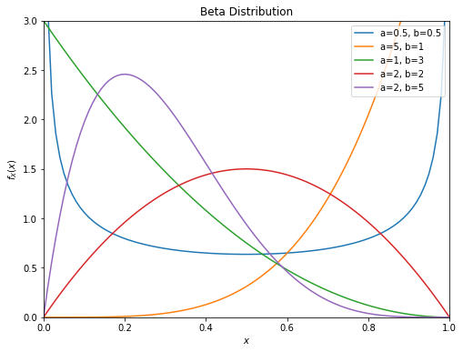

```python
import math
import numpy as np
import matplotlib.pyplot as plt
import scipy.special as sc
%matplotlib inline

def beta_pdf(x,a,b):
    return (x**(a-1))*((1-x)**(b-1))/sc.beta(a,b)

np.seterr(divide = 'ignore')
x=np.linspace(0,1,100)
plt.figure(figsize=(8,6))
parms = [(0.5,0.5),(5,1),(1,3),(2,2),(2,5)] # parameteres
for a,b in parms:
    # ploting the pdf of beta distribution
    plt.plot(x,beta_pdf(x,a,b),label=r"a={0}, b={1}".format(a,b))
plt.legend(loc='upper right')
plt.title(r"Beta Distribution")
plt.xlabel("$x$")
plt.ylabel("$f_X(x)$")
plt.xlim(0,1)
plt.ylim(0,3)
plt.show()
```

**Example:** Let $X_1,X_2,X_3$ are independent and $X_i\sim Exp(1)$ for $i=1,2,3$, then  
$JPDF$ of $(X_1,X_2,X_3)$ is $f_{X_1,X_2,X_3}(x_1,x_2,x_3)=f_{X_1}(x_1)f_{X_2}(x_2)f_{X_3}(x_3)$

$f_{X_1,X_2,X_3}(x_1,x_2,x_3)=\left\{\begin{matrix} e^{-(x_1+x_2+x_3)}& x_1>0,x_2>0,x_3>0 \\ 0&\text{otherwise} \end{matrix}\right.$

Let $Y_1=X_1+X_2+X_3$, $Y_2=\frac{X_1+X_2}{X_1+X_2+X_3}$, and $Y_3=\frac{X_1}{X_1+X_2}$

$S_{Y_1}=(0,\infty)$, $S_{Y_2}=(0,1)$, and $S_{Y_3}=(0,1)$

$y_1=x_1+x_2+x_3$, $y_2=\frac{x_1+x_2}{x_1+x_2+x_3}$, $y_3=\frac{x_1}{x_1+x_2}$

$x_1=y_1y_2y_3,~x_1+x_2=y_1y_2\implies x_2=y_1y_2(1-y_3),$ and $x_3=y_1-(x_1+x_2)\implies x_3=y_1(1-y_2)$

$\frac{\partial (x_1,x_2,x_3)}{\partial(y_1,y_2,y_3)}=\begin{vmatrix} \frac{\partial x_1}{\partial y_1}& \frac{\partial x_1}{\partial y_2} & \frac{\partial x_1}{\partial y_3}\\ \frac{\partial x_2}{\partial y_1}& \frac{\partial x_2}{\partial y_2} & \frac{\partial x_2}{\partial y_3}\\ \frac{\partial x_3}{\partial y_1}& \frac{\partial x_3}{\partial y_2} & \frac{\partial x_3}{\partial y_3} \end{vmatrix}=\begin{vmatrix} y_2y_3&y_1y_3 &y_1y_2 \\ y_2(1-y_3)&y_1(1-y_3) &-y_1y_2 \\ 1-y_2& -y_1 &0 \end{vmatrix}=-y_1^2y_2$

The $JPDF$ of $Y_1,Y_2,Y_3$ is given by

$f_{Y_1,Y_2,Y_3}(y_1,y_2,y_3)=f_{X_1,X_2,X_3}(y_1y_2y_3,y_1y_2(1-y_3),y_1(1-y_2))\begin{vmatrix}\frac{\partial (x_1,x_2,x_3)}{\partial(y_1,y_2,y_3)}\end{vmatrix}$, $y_1>0,0<y_2<1,0<y_3<1$

$=y_1^2y_2e^{-(y_1y_2y_3+y_1y_2(1-y_3)+y_1(1-y_2))}$, $y_1>0,0<y_2<1,0<y_3<1$

$f_{Y_1,Y_2,Y_3}(y_1,y_2,y_3)=\left\{\begin{matrix} y_1^2y_2e^{-y_1}& y_1>0, 0<y_2<1,0<y_3<1 \\ 0&\text{otherwise} \end{matrix}\right.$

- Let $(X,Y)$ is a bivariate continuous random variable with $JPDF$ $f_{X,Y}(x,y)$, and $U=g(X,Y)$. If we are interested in finding the $PDF$ of $U$, we can do the following.

Let $U=g(X,Y)$ and introduce auxiliary transformation $V=h(X,Y)$ so that the transformation $(x,y)\to (g(x,y),h(x,y))$ is one-one

then we can find the $JPDF$ of $(U,V)$, $f_{U,V}(u,v)$, then

then, $PDF$ of $U$, $f_U(u)=\int_{-\infty}^{\infty}f_{U,V}(u,v)dv$

**Note:** Here we may have a lot of choices for $V=h(X,Y)$, but to make problem easy, the simplest choice would be $V=X$ (or) $V=Y$

**Problem:** Let $X,Y$ are two independent standard normal random variable, then find the $PDF$ of $U={X\over Y}$.

*solution:* $JPDF$ of $(X,Y)$, $f_{X,Y}(x,y)=f_X(x)f_Y(y)=\frac{1}{\sqrt{2\pi}}e^{-\frac{x^2}{2}}\times \frac{1}{\sqrt{2\pi}}e^{-\frac{y^2}{2}}$ ($\because~X,Y$ are independent )

$f_{X,Y}(x,y)=\frac{1}{{2\pi}}e^{-\frac{1}{2}(x^2+y^2)}$

Let $U={X\over Y}$, take an auxiliary transformation $V=Y$

$u=\frac{x}{y}$,$v=y$ $\implies x=uv,y=v$

$\frac{\partial (x,y)}{\partial(u,v)}=\begin{vmatrix} \frac{\partial x}{\partial u}& \frac{\partial x}{\partial v}\\ \frac{\partial y}{\partial u}& \frac{\partial y}{\partial v} \end{vmatrix}=\begin{vmatrix} v&u \\ 0&1 \end{vmatrix}=v$

$JPDF$ of $(U,V)$, $f_{U,V}(u,v)=f_{X,Y}(uv,v)\begin{vmatrix}\frac{\partial (x,y)}{\partial (u,v)}\end{vmatrix}$, $-\infty<uv<\infty$,$-\infty<v<\infty$

$f_{U,V}(u,v)=\frac{1}{2\pi}e^{-\frac{1}{2}\left(u^2v^2+v^2\right)}|v|$, $-\infty<u<\infty$, $-\infty<v<\infty$

$PDF$ of $U$, $f_U(u)=\int_{-\infty}^{\infty}f_{U,V}(u,v)dv=\int_{-\infty}^{\infty}\frac{1}{2\pi}e^{-\frac{1}{2}(u^2+1)v^2}|v|dv$

$f_U(u)=\frac{1}{2\pi}\left(2\int_{0}^{\infty}ve^{-\frac{1}{2}(u^2+1)v^2}dv\right)$

Take $t=v^2\implies 2vdv=dt$

$f_U(u)=\frac{1}{2\pi}\int_{0}^{\infty}e^{-\frac{1}{2}(u^2+1)t}dt=\frac{1}{2\pi}\left[\frac{e^{-\frac{1}{2}(u^2+1)t}}{-\frac{1}{2}(u^2+1)}\right]_0^\infty=\frac{1}{2\pi}\left[-0+\frac{1}{\frac{1}{2}(u^2+1)}\right]$

$\therefore$ $f_U(u)=\frac{1}{\pi}\frac{1}{u^2+1},-\infty<u<\infty$

Here we can see that $U= {X\over Y}$ follows **Cauchy distribution**.